Para EU-ProVerde · Expertise France, INSKIP y Afi

# Datalab

Leemos lo publicado, marcamos la brecha y decidimos qué cerrar primero.

Inspira. Actúa. Transforma.

Datalab es el laboratorio de datos de CleantechHUB: estrategia, flujos, living lab y enlaces a plataformas abiertas. Mapea empresas, las filtra, las prioriza y sigue el resultado.

Para pymes verdes, el cribado parte de información pública. El emparejamiento con inversores sigue en Nexus.

93

Perfiles corporativos

3

Datasets de innovación

L1–L5

Niveles de madurez

4

Entornos de trabajo

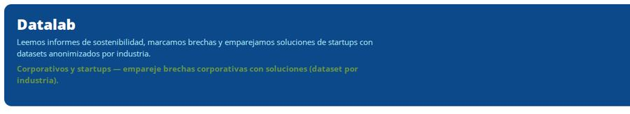

Aplicación

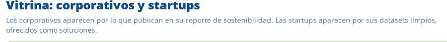

Vitrina

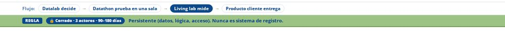

Living lab

## Madurez pública, de L1 a L5

[figure not shown]

**Datalab**Estrategia

**Datathon**Efímero

**Living lab**Persistente

**Producto cliente**Solo lectura

## Mapeo

Cada empresa queda en un mapa de sedes, procesos, activos y temas. El esquema une empresa, sede, proceso, activo, tema, brecha y financiación.

El living lab muestra la calidad del aire en Bogotá: mapa, delta y compuerta ROI. 19 de 19 estaciones en vivo se contrastaron con la capa de la Secretaría Distrital de Ambiente.

## Filtro

El índice del 8 de octubre de 2026, versión 4.1.0, tiene 93 perfiles corporativos y 3 datasets de innovación. El filtro usa nombre, sector y código CIIU.

La madurez pública va de L1 a L5. Los datasets de startups usan la etiqueta de industria, no el nombre del cliente.

## Seguimiento

El recorrido es informe, materialidad, brecha y solución. Si el informe no trae el dato, queda «Pendiente de dato real».

Cuatro entornos reciben el trabajo: Datalab (estrategia), Datathon (efímero), living lab (persistente) y Producto cliente (solo lectura).

[figure not shown]

[figure not shown]